# Sports—Who’s Best of All Time?

# Foundational Concepts

Today we’re going to take on the statistical challenge of analyzing sports statistics, which is a sport of its own.

```r
if (!caracas::has_sympy()) {
  caracas::install_sympy()
}
library(caracas)
library(sets)
library(tibble)
library(ggplot2)
library(dplyr)
```

```r
def_sym("X", "Y")

cmStats <- modules::use("CmStats.R")$cmStats
```

We will discuss the question: “Who is the best hitter in baseball history?” This question immediately presents statistical challenges that concern comparisons of performance in different eras and different circumstances. Next, we will consider the question of streaks. Do athletes enter “the zone” and have a “hot hand” for periods of time? What is the correct interpretation of slumps and streaks? Such questions force us to confront our understanding—or misunderstanding—of what to expect from randomness. The question, “What is random?” lies at the heart of the issue of streaks and slumps.

Who was the best hitter in the history of major league baseball? This question forces us to clarify the relationship between what is measured and what quality we are trying to describe. The batting average is basically de ned as the number of times the batter gets a hit divided by the number of times he is at bat.

All of the 18 highest batting averages in a season in the history of professional major league baseball occurred before 1942. Why?

One way to measure across eras would be to measure how many standard deviations above the mean a batter’s average is. For example, given that Joe Jackson of the Chicago White Sox had a batting average in 1920 that is 2.36 standard deviations above the mean for that year and that Moises Alou of the Houston Astros had a batting average in 2000 that is 2.31 standard deviations above the mean for the year 2000, we might consider those two players about equally good batters. They are about equally extreme outliers.

We could list the 10 batters whose batting averages were the greatest number of standard deviations above the mean for their years and declare a winner on that basis. Stephen Jay Gould opines that pitching, elding, and batting have all gotten better over the years, and their approach to human limits of perfection accounts for the lower standard deviation. Making an interpretation such as Gould’s can be helpful in understanding the data.

Our second statistical issue from sports is the question of the “hot hand.” A commentator is often heard to say, “This player is on a streak. He can’t seem to miss.” Is there really such a thing as a “hot hand,” meaning that the player is better for a period of time? Or are the streaks (which are real) accounted for by random luck alone?

The statistical test used to measure rarity in this example is called a chi-square test. In the example considered in the lecture, the data were not suf ciently extreme to reject the assumption of no hot hand. Thus, the data do not warrant the conclusion that there is a hot hand. Trying to distinguish randomness from some other cause is dif cult. There are many ways to look at a string of data and ask whether the string is explained best as a random process or as a process that is in uenced by 80 something internal to it. There are many ways of looking for patterns. There is room for interpretation.

Trying to nd the greatest hitter in baseball history brought up questions about the relationship between what we measure, what we want to know, and how to compare performances in different eras or under different circumstances. The hot hand issue brought up fundamental questions about the nature, meaning, and measure of randomness.

# Concept and Applications

## ANALYSIS OF VARIANCE: COMPARING 3 MEANS

Variation and randomness are everywhere. Whether you’re looking for a mechanical part failure, determining a new drug’s effectiveness, or wondering if it will rain tomorrow, almost everything has variation. One of the most commonly used statistical methods is ANOVA, which is an acronym for the phrase “analysis of variance.” The whole purpose of ANOVA is to break up variation into component parts and then look at their significance.

### ANALYSIS OF VARIANCE (ANOVA)

Suppose that we have 3 normal distributions and the means are 0, 1, and 2. They’re different, but could they be statistically equivalent and fundamentally the same? In other words, could they have all come from the same underlying population?

ANOVA is used to model situations where our response variable is continuous and our variables explaining or predicting that response are all categorical. ANOVA answers the following questions: Do categories have an effect? How is the effect different across categories? Is this significant? You can think of ANOVA as regression specifically for categorical predictor variables.

Recall the sample variance:

```r
cmStats$S_2_sym
```

```
c:  n
   ____
   ╲
    ╲            2
     ╲   (-X + x)
     ╱   ─────────
    ╱      n - 1
   ╱
   ‾‾‾‾
   i = 1
```

The distance from any data point to the mean is the deviation from this ۧ ۧ point to the mean: ( Xi − X ). The sum of squares is the sum of all squared deviations:

```r
cmStats$SS_sym
```

```
c:   n
    ___
    ╲
     ╲           2
     ╱   (-X + x)
    ╱
    ‾‾‾
   i = 1
```

Variation between groups: For each data value, we look at the difference between its group mean and the overall mean. This is called the sum of squares between ( SSB ), which is the sum of the squared deviations between each group mean and the overall mean weighted by the sample size of each group ( 𝑛group ).

```r
cmStats$SS_B
```

```
c:   n
    ___
    ╲
     ╲                       2
     ╱   n_goup⋅(-X + X_goup)
    ╱
    ‾‾‾
   i = 1
```

Variation within groups: For each data value, we look at the difference between that value and the mean of its group. This is called the sum of squares within ( SSW ), which is the sum of the squared deviations within each group.

```r
cmStats$SS_W_sym
```

```
c:   n
    ___
    ╲
     ╲           2
     ╱   (-X + x)
    ╱
    ‾‾‾
   i = 1
```

The sum of squares total ( SST ) is the sum of the squared deviations between each observation and the overall mean.

```r
cmStats$SS_T_sym
```

```
c:   n
    ___
    ╲
     ╲           2
     ╱   (-X + x)
    ╱
    ‾‾‾
   i = 1
```

In other words, total SS = within-group SS + between-group SS: SST = SSW + SSB.

We assume that the variance σ2 is approximately the same for each of the group’s populations. We can combine the estimates of σ2 across the groups and use an overall estimate for the common population variance.

MSW ( mean square within ) is also called the within-groups mean square.

```r
MSW = cmStats$SS_W_sym / (cmStats$N - cmStats$k)
```

MSB is the mean square between.

```r
MSB = cmStats$SS_B_sym / (cmStats$k - 1)
```

### THE F-STATISTIC

Our goal is to compare the 2 sources of variability: MSW and MSB. Our test statistic is.

```r
F ~ SS_B / (k - 1) / SS_w/ (N - K) ~  MSB/MSW
```

```
F ~ SS_B/(k - 1)/SS_w/(N - K) ~ MSB/MSW
```

```r
MSB/MSW
```

```
c:           n
            ___
            ╲
             ╲                       2
   (N - k)⋅  ╱   n_goup⋅(-X + X_goup)
            ╱
            ‾‾‾
           i = 1
   ───────────────────────────────────
                   n
                  ___
                  ╲
                   ╲           2
         (k - 1)⋅  ╱   (-X + x)
                  ╱
                  ‾‾‾
                 i = 1
```

If H0 is true, −F will be small ( close to 1 ), which means that the between- group variation is about the same as the within-group variation. In other words, the grouping doesn’t explain much variation in the data.

If H0 is not true, −F will be large, which means that the between-group variation explains a lot of the variation in the data, much more than the variance within groups. In other words, the difference between the individual groups is much larger than the difference within each group.

What we’ve just computed is called the F-statistic or F-ratio. Unlike the t-statistic, which is based on sample means, the F-ratio is based on a ratio of sample variances. The variance in the numerator measures the size of differences among sample means. Variance in the denominator measures the other differences expected if group means were not different from one another.

Because F is formed by chi-squared, many of the chi-squared properties carry over to the F-distribution.

The F-values are all non-negative.

- The distribution is non-symmetric.
- The mean is approximately 1.
- There are 2 independent degrees of freedom: 1 for the numerator and 1 for the denominator.

### ANOVA IN R

The ANOVA summary table is a concise method for presenting ANOVA results.

ANOVA requires that the variability of groups be homogeneous. We can observe the box plots to verify this assumption.

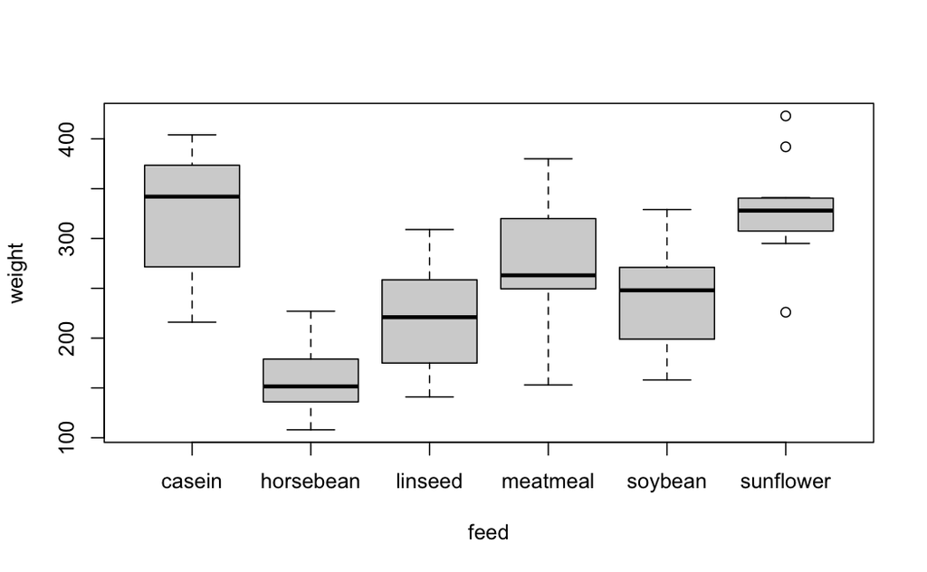

```r
boxplot(weight ~feed, data= chickwts, col= "lightgray")
```

ANOVA also requires the number of cases in your data groups to be approximately the same.

```r
summary(chickwts)
```

```
     weight             feed
 Min.   :108.0   casein   :12
 1st Qu.:204.5   horsebean:10
 Median :258.0   linseed  :12
 Mean   :261.3   meatmeal :11
 3rd Qu.:323.5   soybean  :14
 Max.   :423.0   sunflower:12
```

Our group sizes only range between 10 and 14, but what if we had larger variation in sample size?

If the ANOVA test shows that there is a significant difference in means between the groups, we may want to perform multiple comparisons between all pair-wise means to determine how they differ.

```r
results <-  aov(weight ~ feed, data = chickwts)
summary(results)
```

```
            Df Sum Sq Mean Sq F value   Pr(>F)
feed         5 231129   46226   15.37 5.94e-10 ***
Residuals   65 195556    3009
---
Signif. codes:  0 ‘***’ 0.001 ‘**’ 0.01 ‘*’ 0.05 ‘.’ 0.1 ‘ ’ 1
```

The ANOVA F-test answers the question whether there are significant differences in the k population means. But it doesn’t give us any information about how they differ. That’s because ANOVA compares all individual mean differences simultaneously, in 1 test.

### TUKEY’S METHOD

A common multiple comparisons procedure is Tukey’s method, named for John Tukey, an inventive mathematics professor with a joint appointment at Bell Labs. He was first to use the terms “software” and “bit” in computer science, and in 1970, he created box plots.

Tukey was a prolific inventor of methods, so we also call this Tukey’s honest significance test, sometimes abbreviated as HSD. It’s a single value that determines the minimum difference between treatment means that is necessary to claim statistical significance—a difference large enough that 𝑝 < α experiment-wise.

```r
results <-  aov(weight ~ feed, data =  chickwts)
TukeyHSD(results, conf.level = 0.95)
```

```
  Tukey multiple comparisons of means
    95% family-wise confidence level

Fit: aov(formula = weight ~ feed, data = chickwts)

$feed
                           diff         lwr       upr     p adj
horsebean-casein    -163.383333 -232.346876 -94.41979 0.0000000
linseed-casein      -104.833333 -170.587491 -39.07918 0.0002100
meatmeal-casein      -46.674242 -113.906207  20.55772 0.3324584
soybean-casein       -77.154762 -140.517054 -13.79247 0.0083653
sunflower-casein       5.333333  -60.420825  71.08749 0.9998902
linseed-horsebean     58.550000  -10.413543 127.51354 0.1413329
meatmeal-horsebean   116.709091   46.335105 187.08308 0.0001062
soybean-horsebean     86.228571   19.541684 152.91546 0.0042167
sunflower-horsebean  168.716667   99.753124 237.68021 0.0000000
meatmeal-linseed      58.159091   -9.072873 125.39106 0.1276965
soybean-linseed       27.678571  -35.683721  91.04086 0.7932853
sunflower-linseed    110.166667   44.412509 175.92082 0.0000884
soybean-meatmeal     -30.480519  -95.375109  34.41407 0.7391356
sunflower-meatmeal    52.007576  -15.224388 119.23954 0.2206962
sunflower-soybean     82.488095   19.125803 145.85039 0.0038845
```